# Wrangle and Analyse Data

In the following project I am going to gather and analyze data all around the Twitter account WeRateDogs. For that, data is gathered via manual download, programmatical download and over an API. After that I am going to assess this data, define the issues found during the assessment and clean these issues to get a cleaned master dataframe.

# Libraries needed

```python
import requests #download data
import numpy as np #array functions
import pandas as pd #data handling
import tweepy #twitter api
import json #handle json data
import matplotlib.pyplot as plt #data visualization
import seaborn as sns #data visualization
import re #text processing
```

**Read the csv file**

```python
url = 'https://raw.githubusercontent.com/hiyabose/Data-Analysis/master/twitter-archive-enhanced.csv'
df_twitter = pd.read_csv(url)

df_twitter.head(3)
```

|  | tweet_id | in_reply_to_status_id | in_reply_to_user_id | timestamp | source | text | retweeted_status_id | retweeted_status_user_id | retweeted_status_timestamp | expanded_urls | rating_numerator | rating_denominator | name | doggo | floofer | pupper | puppo |
| --- | --- | --- | --- | --- | --- | --- | --- | --- | --- | --- | --- | --- | --- | --- | --- | --- | --- |
| 0 | 892420643555336193 | NaN | NaN | 2017-08-01 16:23:56 +0000 | <a href="http://twitter.com/download/iphone" r... | This is Phineas. He's a mystical boy. Only eve... | NaN | NaN | NaN | https://twitter.com/dog_rates/status/892420643... | 13 | 10 | Phineas | None | None | None | None |
| 1 | 892177421306343426 | NaN | NaN | 2017-08-01 00:17:27 +0000 | <a href="http://twitter.com/download/iphone" r... | This is Tilly. She's just checking pup on you.... | NaN | NaN | NaN | https://twitter.com/dog_rates/status/892177421... | 13 | 10 | Tilly | None | None | None | None |
| 2 | 891815181378084864 | NaN | NaN | 2017-07-31 00:18:03 +0000 | <a href="http://twitter.com/download/iphone" r... | This is Archie. He is a rare Norwegian Pouncin... | NaN | NaN | NaN | https://twitter.com/dog_rates/status/891815181... | 12 | 10 | Archie | None | None | None | None |

Tweet image predictions (image_predictions.tsv)

To gather this data we are going to define the file - url, request this url and write the content of the response to a separate file.

```python
url = "https://d17h27t6h515a5.cloudfront.net/topher/2017/August/599fd2ad_image-predictions/image-predictions.tsv"

#get response
response = requests.get(url)

#write return to an image
with open("image_predictions.tsv", mode = "wb") as file:
    file.write(response.content)
```

```python
df_predict = pd.read_csv("image_predictions.tsv", sep='\t')

df_predict.head(3)
```

|  | tweet_id | jpg_url | img_num | p1 | p1_conf | p1_dog | p2 | p2_conf | p2_dog | p3 | p3_conf | p3_dog |
| --- | --- | --- | --- | --- | --- | --- | --- | --- | --- | --- | --- | --- |
| 0 | 666020888022790149 | https://pbs.twimg.com/media/CT4udn0WwAA0aMy.jpg | 1 | Welsh_springer_spaniel | 0.465074 | True | collie | 0.156665 | True | Shetland_sheepdog | 0.061428 | True |
| 1 | 666029285002620928 | https://pbs.twimg.com/media/CT42GRgUYAA5iDo.jpg | 1 | redbone | 0.506826 | True | miniature_pinscher | 0.074192 | True | Rhodesian_ridgeback | 0.072010 | True |
| 2 | 666033412701032449 | https://pbs.twimg.com/media/CT4521TWwAEvMyu.jpg | 1 | German_shepherd | 0.596461 | True | malinois | 0.138584 | True | bloodhound | 0.116197 | True |

```python
#keys and token to access the API
consumer_key = 'vhL3DZrG6B7uqGJzPjve24yID'
consumer_secret = 'mh0iZy07tCB6wFR6kv1kEZcEqH7oz5agoYjTDDFSl1DklajImU'
access_token = '1257573345849114625-SSDZM4Z40M6Dk36Y6x1sj7mWMomp3I'
access_secret = 'Y3yGlzJFbNWdkNPazro3GYwvq2pKl41nh5Q4DRxOUsN3E'

#access the API
auth = tweepy.OAuthHandler(consumer_key, consumer_secret)
auth.set_access_token(access_token, access_secret)

api = tweepy.API(auth, wait_on_rate_limit=True, wait_on_rate_limit_notify=True)
```

```python
twitter_ids = list(df_twitter.tweet_id.unique())
```

```python
with open("tweet_json.txt", "w") as file:
  for ids in twitter_ids:
     print(f"Gather id: {ids}")
     try:

        #get all the twitter status - extended mode gives us additional data
        tweet = api.get_status(ids, tweet_mode = "extended")
        #dump the json data to our file
        json.dump(tweet._json, file)
        #add a linebreak after each dump
        file.write('\n')
     except Exception as e:
        print(f"Error - id: {ids}" + str(e))
```

[output not shown]

[output cut: 869 more lines]

[output not shown]

```
Rate limit reached. Sleeping for: 755
```

[output not shown]

[output cut: 847 more lines]

[output not shown]

```
Rate limit reached. Sleeping for: 757
```

[output not shown]

[output cut: 500 more lines]

[output not shown]

```python
api_data = []

#read the created file
with open("tweet_json.txt", "r") as f:
    for line in f:
        try:
            tweet = json.loads(line)
            #append a dictionary to the created list
            api_data.append({
                "tweet_id": tweet["id"],
                "retweet_count": tweet["retweet_count"],
                "favorite_count": tweet["favorite_count"],
                "retweeted": tweet["retweeted"],
                "display_text_range": tweet["display_text_range"]
            })

            #tweet["entities"]["media"][0]["media_url"]
        except:
            print("Error.")

df_api = pd.DataFrame(api_data, columns = ["tweet_id", "retweet_count", "favorite_count", "retweeted", "display_text_range"])
df_api.head()
```

|  | tweet_id | retweet_count | favorite_count | retweeted | display_text_range |
| --- | --- | --- | --- | --- | --- |
| 0 | 892420643555336193 | 7723 | 36281 | False | [0, 85] |
| 1 | 892177421306343426 | 5712 | 31283 | False | [0, 138] |
| 2 | 891815181378084864 | 3786 | 23553 | False | [0, 121] |
| 3 | 891689557279858688 | 7878 | 39567 | False | [0, 79] |
| 4 | 891327558926688256 | 8498 | 37794 | False | [0, 138] |

Thus the JSON file table is created

```python
df_twitter.head(1)
```

|  | tweet_id | in_reply_to_status_id | in_reply_to_user_id | timestamp | source | text | retweeted_status_id | retweeted_status_user_id | retweeted_status_timestamp | expanded_urls | rating_numerator | rating_denominator | name | doggo | floofer | pupper | puppo |
| --- | --- | --- | --- | --- | --- | --- | --- | --- | --- | --- | --- | --- | --- | --- | --- | --- | --- |
| 0 | 892420643555336193 | NaN | NaN | 2017-08-01 16:23:56 +0000 | <a href="http://twitter.com/download/iphone" r... | This is Phineas. He's a mystical boy. Only eve... | NaN | NaN | NaN | https://twitter.com/dog_rates/status/892420643... | 13 | 10 | Phineas | None | None | None | None |

```python
df_predict.head(1)
```

|  | tweet_id | jpg_url | img_num | p1 | p1_conf | p1_dog | p2 | p2_conf | p2_dog | p3 | p3_conf | p3_dog |
| --- | --- | --- | --- | --- | --- | --- | --- | --- | --- | --- | --- | --- |
| 0 | 666020888022790149 | https://pbs.twimg.com/media/CT4udn0WwAA0aMy.jpg | 1 | Welsh_springer_spaniel | 0.465074 | True | collie | 0.156665 | True | Shetland_sheepdog | 0.061428 | True |

```python
df_api.head(1)
```

|  | tweet_id | retweet_count | favorite_count | retweeted | display_text_range |
| --- | --- | --- | --- | --- | --- |
| 0 | 892420643555336193 | 7723 | 36281 | False | [0, 85] |

# Data Assessing

Now we will look at all the dataset and see where we need to clean the data

**df_twitter**

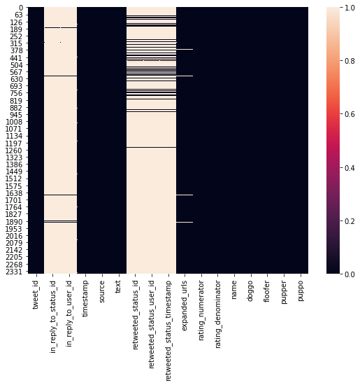

```python
fig, ax = plt.subplots(figsize = (9,7))
ax = sns.heatmap(df_twitter.isnull(), vmin=0, vmax = 1)
```

Here from the visual we can see that there a lot of missing datas in the reply and the retweet section

```python
df_twitter.sample(5)
```

|  | tweet_id | in_reply_to_status_id | in_reply_to_user_id | timestamp | source | text | retweeted_status_id | retweeted_status_user_id | retweeted_status_timestamp | expanded_urls | rating_numerator | rating_denominator | name | doggo | floofer | pupper | puppo |
| --- | --- | --- | --- | --- | --- | --- | --- | --- | --- | --- | --- | --- | --- | --- | --- | --- | --- |
| 1366 | 702671118226825216 | NaN | NaN | 2016-02-25 01:47:04 +0000 | <a href="http://twitter.com/download/iphone" r... | Meet Rambo &amp; Kiwi. Rambo's the pup with th... | NaN | NaN | NaN | https://twitter.com/dog_rates/status/702671118... | 10 | 10 | Rambo | None | None | None | None |
| 2228 | 668256321989451776 | NaN | NaN | 2015-11-22 02:34:57 +0000 | <a href="http://twitter.com/download/iphone" r... | This is Jareld. Jareld rules these waters. Lad... | NaN | NaN | NaN | https://twitter.com/dog_rates/status/668256321... | 13 | 10 | Jareld | None | None | None | None |
| 657 | 791774931465953280 | NaN | NaN | 2016-10-27 22:53:48 +0000 | <a href="http://vine.co" rel="nofollow">Vine -... | Vine will be deeply missed. This was by far my... | NaN | NaN | NaN | https://vine.co/v/ea0OwvPTx9l | 14 | 10 | None | None | None | None | None |
| 2000 | 672488522314567680 | NaN | NaN | 2015-12-03 18:52:12 +0000 | <a href="http://twitter.com/download/iphone" r... | This is Jackie. She was all ready to go out, b... | NaN | NaN | NaN | https://twitter.com/dog_rates/status/672488522... | 10 | 10 | Jackie | None | None | None | None |
| 555 | 803692223237865472 | NaN | NaN | 2016-11-29 20:08:52 +0000 | <a href="http://twitter.com/download/iphone" r... | RT @dog_rates: I present to you... Dog Jesus. ... | 6.914169e+17 | 4.196984e+09 | 2016-01-25 00:26:41 +0000 | https://twitter.com/dog_rates/status/691416866... | 13 | 10 | None | None | None | None | None |

here we can see that the doggo ,floofer , pupper ,puppo has a majority value of None .

```python
df_twitter.info()
```

```
<class 'pandas.core.frame.DataFrame'>
RangeIndex: 2356 entries, 0 to 2355
Data columns (total 17 columns):
 #   Column                      Non-Null Count  Dtype
---  ------                      --------------  -----
 0   tweet_id                    2356 non-null   int64
 1   in_reply_to_status_id       78 non-null     float64
 2   in_reply_to_user_id         78 non-null     float64
 3   timestamp                   2356 non-null   object
 4   source                      2356 non-null   object
 5   text                        2356 non-null   object
 6   retweeted_status_id         181 non-null    float64
 7   retweeted_status_user_id    181 non-null    float64
 8   retweeted_status_timestamp  181 non-null    object
 9   expanded_urls               2297 non-null   object
 10  rating_numerator            2356 non-null   int64
 11  rating_denominator          2356 non-null   int64
 12  name                        2356 non-null   object
 13  doggo                       2356 non-null   object
 14  floofer                     2356 non-null   object
 15  pupper                      2356 non-null   object
 16  puppo                       2356 non-null   object
dtypes: float64(4), int64(3), object(10)
memory usage: 313.0+ KB
```

Also we can see that tbere is incorrect data type

1. tweet_id is int but it should be string
2. timestamp is object but it should be data and time

```python
df_twitter.name.value_counts()
```

```
None         745
a             55
Charlie       12
Lucy          11
Oliver        11
            ...
Naphaniel      1
Emma           1
Kaia           1
Laela          1
Ralphé         1
Name: name, Length: 957, dtype: int64
```

Here we can see that there are many wrong name like "None", "a", "the" etc.

```python
#to check the duplicated data
df_twitter[df_twitter.duplicated()]
```

|  | tweet_id | in_reply_to_status_id | in_reply_to_user_id | timestamp | source | text | retweeted_status_id | retweeted_status_user_id | retweeted_status_timestamp | expanded_urls | rating_numerator | rating_denominator | name | doggo | floofer | pupper | puppo |
| --- | --- | --- | --- | --- | --- | --- | --- | --- | --- | --- | --- | --- | --- | --- | --- | --- | --- |

we can see that there is no duplicated data

```python
#how many unique tweet id
df_twitter.tweet_id.nunique()
```

```
2356
```

This also proves that there are no duplicated values since the entire data set has unique tweet_ids

```python
df_twitter_assess = df_twitter.copy()
```

```python
#returns true if there is no dog classification in any of the columns
df_twitter_assess[["doggo","floofer","pupper","puppo"]].apply(lambda x: True if
    (x[0] == "None" and x[1] == "None" and x[2] == "None" and x[3] =="None")
    else False, axis = 1).value_counts()
```

```
True     1976
False     380
dtype: int64
```

```python
df_twitter_assess["doggo"].value_counts()
```

```
None     2259
doggo      97
Name: doggo, dtype: int64
```

```python
df_twitter_assess["floofer"].value_counts()
```

```
None       2346
floofer      10
Name: floofer, dtype: int64
```

```python
df_twitter_assess["pupper"].value_counts()
```

```
None      2099
pupper     257
Name: pupper, dtype: int64
```

```python
df_twitter_assess["puppo"].value_counts()
```

```
None     2326
puppo      30
Name: puppo, dtype: int64
```

```python
(380/2356) * 100
```

```
16.129032258064516
```

So we can see that only about 16% of the data is not missing.

Now lets have a look at the Ratings

```python
df_twitter.rating_numerator.value_counts()
```

```
12      558
11      464
10      461
13      351
9       158
8       102
7        55
14       54
5        37
6        32
3        19
4        17
1         9
2         9
420       2
```

[output cut: 26 more lines]

Here we can see that the highest Rating is 1776 and the lowest is 0. So lets see them in details

```python
print(df_twitter.query("rating_numerator == '1776'").text)
```

```
979    This is Atticus. He's quite simply America af....
Name: text, dtype: object
```

```python
print(df_twitter.query("rating_numerator == '1'").text)
```

```
605     RT @dog_rates: Not familiar with this breed. N...
1446    After reading the comments I may have overesti...
1869    What kind of person sends in a picture without...
1940    The millennials have spoken and we've decided ...
2038    After 22 minutes of careful deliberation this ...
2091    Flamboyant pup here. Probably poisonous. Won't...
2261    Never seen dog like this. Breathes heavy. Tilt...
2335    This is an Albanian 3 1/2 legged  Episcopalian...
2338    Not familiar with this breed. No tail (weird)....
Name: text, dtype: object
```

Here we can see that 18669 sends a photo without a dog and 2335 is being misinterpreted

```python
print(df_twitter.query("rating_numerator == '0'").text)
```

```
315     When you're so blinded by your systematic plag...
1016    PUPDATE: can't see any. Even if I could, I cou...
Name: text, dtype: object
```

We can see here the dogs photos are not clear

```python
#now lets check the denominator values
df_twitter.rating_denominator.value_counts()
```

```
10     2333
11        3
50        3
80        2
20        2
2         1
16        1
40        1
70        1
15        1
90        1
110       1
120       1
130       1
150       1
170       1
7         1
0         1
Name: rating_denominator, dtype: int64
```

We can see that the highest denominator is 170 and the lowest is zero

```python
print(df_twitter.query("rating_denominator == '170'").text)
```

```
1120    Say hello to this unbelievably well behaved sq...
Name: text, dtype: object
```

```python
print(df_twitter.query("rating_denominator == '0'").text)
```

```
313    @jonnysun @Lin_Manuel ok jomny I know you're e...
Name: text, dtype: object
```

```python
print(df_twitter.query("rating_denominator == '7'").text)
```

```
516    Meet Sam. She smiles 24/7 &amp; secretly aspir...
Name: text, dtype: object
```

```python
#this is to extract all the actual ratings and split the denom and num into seperate columns
pattern = "(\d+(\.\d+)?\/\d+(\.\d+)?)"
df_twitter_assess["rating"] = df_twitter_assess.text.str.extract(pattern, expand = True)[0]
df_twitter_assess[['num', 'denom']] = df_twitter_assess['rating'].str.split('/', n=1, expand=True)
```

```python
df_twitter_assess.rating_numerator = df_twitter_assess.rating_numerator.astype("str")
df_twitter_assess.rating_denominator = df_twitter_assess.rating_denominator.astype("str")
```

```python
df_twitter_assess["check_num"] = df_twitter_assess[["rating_numerator", "num"]].apply(lambda x: False if (x[0] != x[1]) else True, axis = 1)
```

```python
df_twitter_assess.check_num.value_counts()
```

```
True     2349
False       7
Name: check_num, dtype: int64
```

```python
df_twitter_assess.query("check_num == False")[["rating_numerator", "num","check_num"]]
```

|  | rating_numerator | num | check_num |
| --- | --- | --- | --- |
| 45 | 5 | 13.5 | False |
| 340 | 75 | 9.75 | False |
| 387 | 7 | 007 | False |
| 695 | 75 | 9.75 | False |
| 763 | 27 | 11.27 | False |
| 1689 | 5 | 9.5 | False |
| 1712 | 26 | 11.26 | False |

These are the differences we found by extracting the first occurrence of the pattern. These ratings got transformed to integers and are therefore wrong.

```python
df_twitter_assess[["rating_numerator", "num", "check_num"]].sample(15)
```

|  | rating_numerator | num | check_num |
| --- | --- | --- | --- |
| 583 | 11 | 11 | True |
| 952 | 11 | 11 | True |
| 459 | 13 | 13 | True |
| 1321 | 12 | 12 | True |
| 12 | 13 | 13 | True |
| 1976 | 8 | 8 | True |
| 1886 | 13 | 13 | True |
| 2315 | 8 | 8 | True |
| 351 | 12 | 12 | True |
| 623 | 13 | 13 | True |
| 962 | 11 | 11 | True |
| 1840 | 10 | 10 | True |
| 169 | 12 | 12 | True |
| 1363 | 6 | 6 | True |
| 1110 | 10 | 10 | True |

```python
#doing the same for denominator
df_twitter_assess["check_denom"] = df_twitter_assess[["rating_denominator", "denom"]].apply(lambda x: False if (x[0] != x[1]) else True, axis = 1)
```

```python
df_twitter_assess.check_denom.value_counts()
```

```
True     2355
False       1
Name: check_denom, dtype: int64
```

```python
df_twitter_assess.query("check_denom == False")[["rating_denominator", "denom","check_denom"]]
```

|  | rating_denominator | denom | check_denom |
| --- | --- | --- | --- |
| 313 | 0 | 00 | False |

Its not a issue. we can keep the data same

```python
df_twitter_assess[["rating_denominator", "denom", "check_denom"]].sample(5)
```

|  | rating_denominator | denom | check_denom |
| --- | --- | --- | --- |
| 1677 | 10 | 10 | True |
| 987 | 10 | 10 | True |
| 1751 | 10 | 10 | True |
| 1794 | 10 | 10 | True |
| 1434 | 10 | 10 | True |

Now lets asssess the data to look how many times there are multiple ratings

```python
df_twitter_assess["count"] = df_twitter_assess.text.str.count(pattern)
```

```python
df_twitter_assess["count"].value_counts()
```

```
1    2323
2      32
3       1
Name: count, dtype: int64
```

```python
#show the full text
pd.set_option('display.max_columns', 500)
pd.set_option('display.max_colwidth', 4000)

df_twitter_assess[["text", "count"]].query("count != 1")
```

|  | text | count |
| --- | --- | --- |
| 55 | @roushfenway These are good dogs but 17/10 is an emotional impulse rating. More like 13/10s | 2 |
| 313 | @jonnysun @Lin_Manuel ok jomny I know you're excited but 960/00 isn't a valid rating, 13/10 is tho | 2 |
| 561 | RT @dog_rates: "Yep... just as I suspected. You're not flossing." 12/10 and 11/10 for the pup not flossing https://t.co/SuXcI9B7pQ | 2 |
| 766 | "Yep... just as I suspected. You're not flossing." 12/10 and 11/10 for the pup not flossing https://t.co/SuXcI9B7pQ | 2 |
| 784 | RT @dog_rates: After so many requests, this is Bretagne. She was the last surviving 9/11 search dog, and our second ever 14/10. RIP https:/… | 2 |
| 860 | RT @dog_rates: Meet Eve. She's a raging alcoholic 8/10 (would b 11/10 but pupper alcoholism is a tragic issue that I can't condone) https:/… | 2 |
| 1007 | This is Bookstore and Seaweed. Bookstore is tired and Seaweed is an asshole. 10/10 and 7/10 respectively https://t.co/eUGjGjjFVJ | 2 |
| 1068 | After so many requests, this is Bretagne. She was the last surviving 9/11 search dog, and our second ever 14/10. RIP https://t.co/XAVDNDaVgQ | 2 |
| 1165 | Happy 4/20 from the squad! 13/10 for all https://t.co/eV1diwds8a | 2 |
| 1202 | This is Bluebert. He just saw that both #FinalFur match ups are split 50/50. Amazed af. 11/10 https://t.co/Kky1DPG4iq | 2 |
| 1222 | Meet Travis and Flurp. Travis is pretty chill but Flurp can't lie down properly. 10/10 &amp; 8/10\nget it together Flurp https://t.co/Akzl5ynMmE | 2 |
| 1359 | This is Socks. That water pup w the super legs just splashed him. Socks did not appreciate that. 9/10 and 2/10 https://t.co/8rc5I22bBf | 2 |
| 1459 | This may be the greatest video I've ever been sent. 4/10 for Charles the puppy, 13/10 overall. (Vid by @stevenxx_) https://t.co/uaJmNgXR2P | 2 |
| 1465 | Meet Oliviér. He takes killer selfies. Has a dog of his own. It leaps at random &amp; can't bark for shit. 10/10 &amp; 5/10 https://t.co/6NgsQJuSBJ | 2 |
| 1508 | When bae says they can't go out but you see them with someone else that same night. 5/10 &amp; 10/10 for heartbroken pup https://t.co/aenk0KpoWM | 2 |
| 1525 | This is Eriq. His friend just reminded him of last year's super bowl. Not cool friend\n10/10 for Eriq\n6/10 for friend https://t.co/PlEXTofdpf | 2 |
| 1538 | Meet Fynn &amp; Taco. Fynn is an all-powerful leaf lord and Taco is in the wrong place at the wrong time. 11/10 &amp; 10/10 https://t.co/MuqHPvtL8c | 2 |
| 1662 | This is Darrel. He just robbed a 7/11 and is in a high speed police chase. Was just spotted by the helicopter 10/10 https://t.co/7EsP8LmSp5 | 2 |
| 1795 | Meet Tassy &amp; Bee. Tassy is pretty chill, but Bee is convinced the Ruffles are haunted. 10/10 &amp; 11/10 respectively https://t.co/fgORpmTN9C | 2 |
| 1832 | These two pups just met and have instantly bonded. Spectacular scene. Mesmerizing af. 10/10 and 7/10 for blue dog https://t.co/gwryaJO4tC | 2 |
| 1897 | Meet Rufio. He is unaware of the pink legless pupper wrapped around him. Might want to get that checked 10/10 &amp; 4/10 https://t.co/KNfLnYPmYh | 2 |
| 1901 | Two gorgeous dogs here. Little waddling dog is a rebel. Refuses to look at camera. Must be a preteen. 5/10 &amp; 8/10 https://t.co/YPfw7oahbD | 2 |
| 1970 | Meet Eve. She's a raging alcoholic 8/10 (would b 11/10 but pupper alcoholism is a tragic issue that I can't condone) https://t.co/U36HYQIijg | 2 |
| 2010 | 10/10 for dog. 7/10 for cat. 12/10 for human. Much skill. Would pet all https://t.co/uhx5gfpx5k | 3 |
| 2064 | Meet Holly. She's trying to teach small human-like pup about blocks but he's not paying attention smh. 11/10 &amp; 8/10 https://t.co/RcksaUrGNu | 2 |
| 2113 | Meet Hank and Sully. Hank is very proud of the pumpkin they found and Sully doesn't give a shit. 11/10 and 8/10 https://t.co/cwoP1ftbrj | 2 |
| 2177 | Here we have Pancho and Peaches. Pancho is a Condoleezza Gryffindor, and Peaches is just an asshole. 10/10 &amp; 7/10 https://t.co/Lh1BsJrWPp | 2 |
| 2216 | This is Spark. He's nervous. Other dog hasn't moved in a while. Won't come when called. Doesn't fetch well 8/10&amp;1/10 https://t.co/stEodX9Aba | 2 |
| 2263 | This is Kial. Kial is either wearing a cape, which would be rad, or flashing us, which would be rude. 10/10 or 4/10 https://t.co/8zcwIoiuqR | 2 |
| 2272 | Two dogs in this one. Both are rare Jujitsu Pythagoreans. One slightly whiter than other. Long legs. 7/10 and 8/10 https://t.co/ITxxcc4v9y | 2 |
| 2298 | After much debate this dog is being upgraded to 10/10. I repeat 10/10 | 2 |
| 2306 | These are Peruvian Feldspars. Their names are Cupit and Prencer. Both resemble Rand Paul. Sick outfits 10/10 &amp; 10/10 https://t.co/ZnEMHBsAs1 | 2 |
| 2335 | This is an Albanian 3 1/2 legged Episcopalian. Loves well-polished hardwood flooring. Penis on the collar. 9/10 https://t.co/d9NcXFKwLv | 2 |

We can see that:

```
this data contains retweets (as mentioned before)
sometimes there are multiple dogs/cats or else in one picture
some of these ratings are not clear
```

**df_Predict**

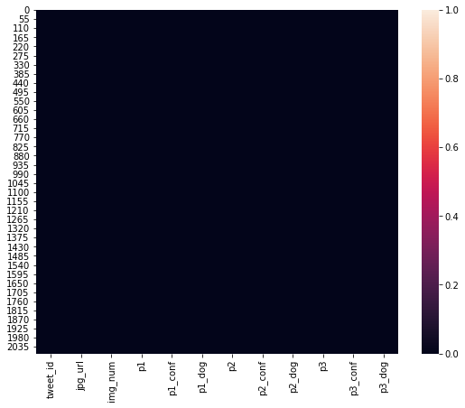

```python
fig, ax = plt.subplots(figsize = (9,7))
ax = sns.heatmap(df_predict.isnull(), vmin = 0, vmax = 1)
```

It looks perfect with no missing data

```python
df_predict.sample(10)
```

|  | tweet_id | jpg_url | img_num | p1 | p1_conf | p1_dog | p2 | p2_conf | p2_dog | p3 | p3_conf | p3_dog |
| --- | --- | --- | --- | --- | --- | --- | --- | --- | --- | --- | --- | --- |
| 451 | 674743008475090944 | https://pbs.twimg.com/media/CV0rL7RWEAAbhqm.jpg | 1 | Bernese_mountain_dog | 0.583054 | True | Shetland_sheepdog | 0.065990 | True | Greater_Swiss_Mountain_dog | 0.065236 | True |
| 320 | 671789708968640512 | https://pbs.twimg.com/tweet_video_thumb/CVKtH-4WIAAmiQ5.png | 1 | dalmatian | 0.114259 | True | teddy | 0.062275 | False | steam_locomotive | 0.049700 | False |
| 1793 | 831262627380748289 | https://pbs.twimg.com/media/C4k88lGVMAEKNzb.jpg | 1 | cocker_spaniel | 0.263323 | True | Brittany_spaniel | 0.200550 | True | doormat | 0.193414 | False |
| 567 | 678341075375947776 | https://pbs.twimg.com/media/CWnznDTU4AAa-6P.jpg | 1 | golden_retriever | 0.853284 | True | cocker_spaniel | 0.026230 | True | Labrador_retriever | 0.024123 | True |
| 1749 | 823699002998870016 | https://pbs.twimg.com/media/C25d3nkXEAAFBUN.jpg | 1 | cairn | 0.203999 | True | snorkel | 0.171893 | False | Norfolk_terrier | 0.107543 | True |
| 935 | 703407252292673536 | https://pbs.twimg.com/media/CcMBJODUsAI5-A9.jpg | 1 | doormat | 0.201058 | False | turnstile | 0.088583 | False | carton | 0.082924 | False |
| 292 | 671186162933985280 | https://pbs.twimg.com/media/CVCIQX7UkAEzqh_.jpg | 1 | Chihuahua | 0.319106 | True | whippet | 0.169134 | True | toy_terrier | 0.125815 | True |
| 690 | 684195085588783105 | https://pbs.twimg.com/media/CX6_y6OU0AAl3v2.jpg | 1 | Chihuahua | 0.379365 | True | toy_terrier | 0.121809 | True | Boston_bull | 0.095981 | True |
| 604 | 679854723806179328 | https://pbs.twimg.com/media/CW9UQ7oWkAAErmU.jpg | 1 | llama | 0.887963 | False | ram | 0.095021 | False | chow | 0.002307 | True |
| 36 | 666447344410484738 | https://pbs.twimg.com/media/CT-yU5QWwAEjLX5.jpg | 1 | curly-coated_retriever | 0.322084 | True | giant_schnauzer | 0.287955 | True | Labrador_retriever | 0.166331 | True |

We can see that:

1.the predicitions are sometimes lowercase, sometimes uppercase

1. there is an underscore instead of a whitespace between the words
2. there are rows with no prediciton of a dog (neither in 1, 2 nor 3)

```python
df_predict.info()
```

```
<class 'pandas.core.frame.DataFrame'>
RangeIndex: 2075 entries, 0 to 2074
Data columns (total 12 columns):
 #   Column    Non-Null Count  Dtype
---  ------    --------------  -----
 0   tweet_id  2075 non-null   int64
 1   jpg_url   2075 non-null   object
 2   img_num   2075 non-null   int64
 3   p1        2075 non-null   object
 4   p1_conf   2075 non-null   float64
 5   p1_dog    2075 non-null   bool
 6   p2        2075 non-null   object
 7   p2_conf   2075 non-null   float64
 8   p2_dog    2075 non-null   bool
 9   p3        2075 non-null   object
 10  p3_conf   2075 non-null   float64
 11  p3_dog    2075 non-null   bool
dtypes: bool(3), float64(3), int64(2), object(4)
memory usage: 152.1+ KB
```

Here again the tweet id should be string

```python
#to check the duplicated values
df_predict.jpg_url.value_counts().head(10)
```

```
https://pbs.twimg.com/media/CU3mITUWIAAfyQS.jpg                                            2
https://pbs.twimg.com/media/Cbs3DOAXIAAp3Bd.jpg                                            2
https://pbs.twimg.com/media/CvoBPWRWgAA4het.jpg                                            2
https://pbs.twimg.com/media/CtKHLuCWYAA2TTs.jpg                                            2
https://pbs.twimg.com/ext_tw_video_thumb/817423809049493505/pu/img/5OFW0yueFu9oTUiQ.jpg    2
https://pbs.twimg.com/media/CVMOlMiWwAA4Yxl.jpg                                            2
https://pbs.twimg.com/ext_tw_video_thumb/815965888126062592/pu/img/JleSw4wRhgKDWQj5.jpg    2
https://pbs.twimg.com/media/Cveg1-NXgAASaaT.jpg                                            2
https://pbs.twimg.com/media/CdHwZd0VIAA4792.jpg                                            2
https://pbs.twimg.com/media/CtzKC7zXEAALfSo.jpg                                            2
Name: jpg_url, dtype: int64
```

```python
df_predict[df_predict.tweet_id.duplicated()]
```

|  | tweet_id | jpg_url | img_num | p1 | p1_conf | p1_dog | p2 | p2_conf | p2_dog | p3 | p3_conf | p3_dog |
| --- | --- | --- | --- | --- | --- | --- | --- | --- | --- | --- | --- | --- |

```python
df_predict[df_predict.jpg_url == "https://pbs.twimg.com/media/CzG425nWgAAnP7P.jpg"]
```

|  | tweet_id | jpg_url | img_num | p1 | p1_conf | p1_dog | p2 | p2_conf | p2_dog | p3 | p3_conf | p3_dog |
| --- | --- | --- | --- | --- | --- | --- | --- | --- | --- | --- | --- | --- |
| 1638 | 806629075125202948 | https://pbs.twimg.com/media/CzG425nWgAAnP7P.jpg | 2 | Arabian_camel | 0.366248 | False | house_finch | 0.209852 | False | cocker_spaniel | 0.046403 | True |
| 1944 | 861769973181624320 | https://pbs.twimg.com/media/CzG425nWgAAnP7P.jpg | 2 | Arabian_camel | 0.366248 | False | house_finch | 0.209852 | False | cocker_spaniel | 0.046403 | True |

```python
df_twitter[df_twitter.tweet_id ==861769973181624320]
```

|  | tweet_id | in_reply_to_status_id | in_reply_to_user_id | timestamp | source | text | retweeted_status_id | retweeted_status_user_id | retweeted_status_timestamp | expanded_urls | rating_numerator | rating_denominator | name | doggo | floofer | pupper | puppo |
| --- | --- | --- | --- | --- | --- | --- | --- | --- | --- | --- | --- | --- | --- | --- | --- | --- | --- |
| 155 | 861769973181624320 | NaN | NaN | 2017-05-09 02:29:07 +0000 | <a href="http://twitter.com/download/iphone" rel="nofollow">Twitter for iPhone</a> | RT @dog_rates: "Good afternoon class today we're going to learn what makes a good boy so good" 13/10 https://t.co/f1h2Fsalv9 | 8.066291e+17 | 4.196984e+09 | 2016-12-07 22:38:52 +0000 | https://twitter.com/dog_rates/status/806629075125202948/photo/1,https://twitter.com/dog_rates/status/806629075125202948/photo/1,https://twitter.com/dog_rates/status/806629075125202948/photo/1,https://… | 13 | 10 | None | None | None | None | None |

```python
df_predict.query("p1_dog == False and p2_dog == False and p3_dog == False")
```

|  | tweet_id | jpg_url | img_num | p1 | p1_conf | p1_dog | p2 | p2_conf | p2_dog | p3 | p3_conf | p3_dog |
| --- | --- | --- | --- | --- | --- | --- | --- | --- | --- | --- | --- | --- |
| 6 | 666051853826850816 | https://pbs.twimg.com/media/CT5KoJ1WoAAJash.jpg | 1 | box_turtle | 0.933012 | False | mud_turtle | 0.045885 | False | terrapin | 0.017885 | False |
| 17 | 666104133288665088 | https://pbs.twimg.com/media/CT56LSZWoAAlJj2.jpg | 1 | hen | 0.965932 | False | cock | 0.033919 | False | partridge | 0.000052 | False |
| 18 | 666268910803644416 | https://pbs.twimg.com/media/CT8QCd1WEAADXws.jpg | 1 | desktop_computer | 0.086502 | False | desk | 0.085547 | False | bookcase | 0.079480 | False |
| 21 | 666293911632134144 | https://pbs.twimg.com/media/CT8mx7KW4AEQu8N.jpg | 1 | three-toed_sloth | 0.914671 | False | otter | 0.015250 | False | great_grey_owl | 0.013207 | False |
| 25 | 666362758909284353 | https://pbs.twimg.com/media/CT9lXGsUcAAyUFt.jpg | 1 | guinea_pig | 0.996496 | False | skunk | 0.002402 | False | hamster | 0.000461 | False |
| ... | ... | ... | ... | ... | ... | ... | ... | ... | ... | ... | ... | ... |
| 2021 | 880935762899988482 | https://pbs.twimg.com/media/DDm2Z5aXUAEDS2u.jpg | 1 | street_sign | 0.251801 | False | umbrella | 0.115123 | False | traffic_light | 0.069534 | False |
| 2022 | 881268444196462592 | https://pbs.twimg.com/media/DDrk-f9WAAI-WQv.jpg | 1 | tusker | 0.473303 | False | Indian_elephant | 0.245646 | False | ibex | 0.055661 | False |
| 2046 | 886680336477933568 | https://pbs.twimg.com/media/DE4fEDzWAAAyHMM.jpg | 1 | convertible | 0.738995 | False | sports_car | 0.139952 | False | car_wheel | 0.044173 | False |
| 2052 | 887517139158093824 | https://pbs.twimg.com/ext_tw_video_thumb/887517108413886465/pu/img/WanJKwssZj4VJvL9.jpg | 1 | limousine | 0.130432 | False | tow_truck | 0.029175 | False | shopping_cart | 0.026321 | False |
| 2074 | 892420643555336193 | https://pbs.twimg.com/media/DGKD1-bXoAAIAUK.jpg | 1 | orange | 0.097049 | False | bagel | 0.085851 | False | banana | 0.076110 | False |

324 rows × 12 columns

```python
df_predict.query("p1_dog == False and (p2_dog == True or p3_dog == True)")
```

|  | tweet_id | jpg_url | img_num | p1 | p1_conf | p1_dog | p2 | p2_conf | p2_dog | p3 | p3_conf | p3_dog |
| --- | --- | --- | --- | --- | --- | --- | --- | --- | --- | --- | --- | --- |
| 8 | 666057090499244032 | https://pbs.twimg.com/media/CT5PY90WoAAQGLo.jpg | 1 | shopping_cart | 0.962465 | False | shopping_basket | 0.014594 | False | golden_retriever | 0.007959 | True |
| 22 | 666337882303524864 | https://pbs.twimg.com/media/CT9OwFIWEAMuRje.jpg | 1 | ox | 0.416669 | False | Newfoundland | 0.278407 | True | groenendael | 0.102643 | True |
| 33 | 666430724426358785 | https://pbs.twimg.com/media/CT-jNYqW4AAPi2M.jpg | 1 | llama | 0.505184 | False | Irish_terrier | 0.104109 | True | dingo | 0.062071 | False |
| 43 | 666776908487630848 | https://pbs.twimg.com/media/CUDeDoWUYAAD-EM.jpg | 1 | seat_belt | 0.375057 | False | miniature_pinscher | 0.167175 | True | Chihuahua | 0.086951 | True |
| 52 | 666996132027977728 | https://pbs.twimg.com/media/CUGlb6iUwAITEbW.jpg | 1 | hay | 0.507637 | False | Rottweiler | 0.062490 | True | water_buffalo | 0.048425 | False |
| ... | ... | ... | ... | ... | ... | ... | ... | ... | ... | ... | ... | ... |
| 1984 | 872122724285648897 | https://pbs.twimg.com/media/DBpm-5UXcAUeCru.jpg | 1 | basketball | 0.808396 | False | pug | 0.066736 | True | dalmatian | 0.054570 | True |
| 1992 | 873697596434513921 | https://pbs.twimg.com/media/DA7iHL5U0AA1OQo.jpg | 1 | laptop | 0.153718 | False | French_bulldog | 0.099984 | True | printer | 0.077130 | False |
| 2013 | 879376492567855104 | https://pbs.twimg.com/media/DDQsQGFV0AAw6u9.jpg | 1 | tricycle | 0.663601 | False | Labrador_retriever | 0.033496 | True | Pembroke | 0.018827 | True |
| 2026 | 882045870035918850 | https://pbs.twimg.com/media/DD2oCl2WAAEI_4a.jpg | 1 | web_site | 0.949591 | False | dhole | 0.017326 | False | golden_retriever | 0.006941 | True |
| 2071 | 891689557279858688 | https://pbs.twimg.com/media/DF_q7IAWsAEuuN8.jpg | 1 | paper_towel | 0.170278 | False | Labrador_retriever | 0.168086 | True | spatula | 0.040836 | False |

219 rows × 12 columns

After looking at some pictures it is clear that some dogs pictures are not properly visible

**df_api**

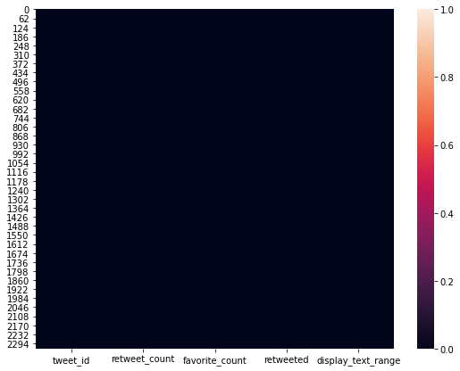

```python
fig, ax = plt.subplots(figsize = (9,7))
ax = sns.heatmap(df_api.isnull(), vmin = 0, vmax = 1)
```

we can see that there is no missing values

```python
df_api.sample(10)
```

|  | tweet_id | retweet_count | favorite_count | retweeted | display_text_range |
| --- | --- | --- | --- | --- | --- |
| 496 | 811647686436880384 | 760 | 5724 | False | [0, 136] |
| 1597 | 684926975086034944 | 460 | 3490 | False | [0, 140] |
| 169 | 857746408056729600 | 10171 | 33147 | False | [0, 137] |
| 611 | 794355576146903043 | 10575 | 0 | False | [0, 118] |
| 2223 | 667866724293877760 | 983 | 2910 | False | [0, 140] |
| 146 | 862722525377298433 | 3343 | 16405 | False | [0, 135] |
| 1997 | 672068090318987265 | 498 | 1250 | False | [0, 138] |
| 767 | 774639387460112384 | 1756 | 6832 | False | [0, 76] |
| 524 | 806242860592926720 | 11924 | 0 | False | [0, 137] |
| 970 | 748568946752774144 | 670 | 2203 | False | [0, 85] |

```python
df_api.info()
```

```
<class 'pandas.core.frame.DataFrame'>
RangeIndex: 2331 entries, 0 to 2330
Data columns (total 5 columns):
 #   Column              Non-Null Count  Dtype
---  ------              --------------  -----
 0   tweet_id            2331 non-null   int64
 1   retweet_count       2331 non-null   int64
 2   favorite_count      2331 non-null   int64
 3   retweeted           2331 non-null   bool
 4   display_text_range  2331 non-null   object
dtypes: bool(1), int64(3), object(1)
memory usage: 75.2+ KB
```

This dataset looks okay. There is no missing values and only thing that needs to be changed is tweet id datatype to string

# Quality

df_twitter table

1. the datatype of the id - columns is integer and should be str
2. the datatype of the timestamp - column is object and should be datetime
3. some of the dogs are not classified as one of "doggo", "floofer", "pupper" or "puppo" and contain all "None" instead
4. some of the dog names are not correct (None, an, by, a, ...) contains retweets
5. some of the ratings are not correctly extracted (mostly if there are >1 entries with the pattern "(\d+(.\d+)?\/\d+(.\d+)?)"
6. also transforming the ratings to integer created some mistakes (there are also floats)
7. the source column contains html code

df_predict table

```
1. the datatype of the id - columns is integer and should be str
2. contains retweets (duplicated rows in column jpg_url)
3. there are pictures in this table that are not dogs
4. the predictions are sometimes uppercase, sometimes lowercase
5. also there is a "_" instead of a whitespace in the predictions
```

df_api table

```
1. the datatype of the id - columns is integer and should be str
```

# Tidiness

df_twitter table

```
1. the columns doggo, floofer,pupper and puppo are not easy to analyze and should be in one column
```

df_predict table

```
1. the prediction and confidence columns should be reduced to two columns - one for the prediction with the highest confidence (dog)
```

df_api table

1. display_text_range contains 2 variables

all tables

```
1. All three tables share the column tweet_id and should be merged together.
```

# Data Cleaning

Cleaning steps:

```
1. Merge the tables together
2. Drop the replies, retweets and the corresponding columns and also drop the tweets without an image or with images which don't display doggos
3. Clean the datatypes of the columns
4. Clean the wrong numerators - the floats on the one hand (replacement), the ones with multiple occurence of the pattern on the other (drop)
5. Extract the source from html code
6. Split the text range into two separate columns
7. Remove the "None" out of the doggo, floofer, pupper and puppo column and merge them into one column
8. Remove the wrong names of name column
9. Reduce the prediction columns into two - breed and conf
10. Clean the new breed column by replacing the "_" with a whitespace and make them all lowercase
```

Define:

merge the tables

code

```python
#outer join to not loose rows at first
df_master = pd.merge(df_twitter, df_api, on = "tweet_id", how = "outer")
```

```python
df_master = pd.merge(df_master, df_predict, on = "tweet_id", how = "outer")
```

```python
df_master_clean = df_master.copy()
```

test

```python
df_master_clean.info()
```

```
<class 'pandas.core.frame.DataFrame'>
Int64Index: 2356 entries, 0 to 2355
Data columns (total 32 columns):
 #   Column                      Non-Null Count  Dtype
---  ------                      --------------  -----
 0   tweet_id                    2356 non-null   int64
 1   in_reply_to_status_id       78 non-null     float64
 2   in_reply_to_user_id         78 non-null     float64
 3   timestamp                   2356 non-null   object
 4   source                      2356 non-null   object
 5   text                        2356 non-null   object
 6   retweeted_status_id         181 non-null    float64
 7   retweeted_status_user_id    181 non-null    float64
 8   retweeted_status_timestamp  181 non-null    object
 9   expanded_urls               2297 non-null   object
```

[output cut: 24 more lines]

Define:

Drop the replies, retweets and the corresponding columns and also drop the tweets without an image or with images which don't display doggos

Code:

we can see that there are a lot of missing values...let's visualise it

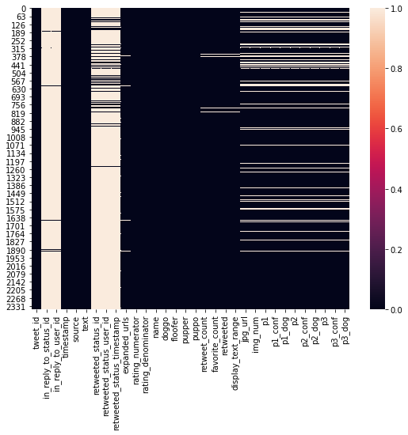

```python
fig, ax = plt.subplots(figsize = (9,7))
ax = sns.heatmap(df_master_clean.isnull(), vmin = 0, vmax = 1)
```

```python
pd.set_option('display.max_colwidth', 50) #to set the column width
df_master_clean[df_master_clean["retweeted"].isnull()] #to check the empty rows
```

|  | tweet_id | in_reply_to_status_id | in_reply_to_user_id | timestamp | source | text | retweeted_status_id | retweeted_status_user_id | retweeted_status_timestamp | expanded_urls | rating_numerator | rating_denominator | name | doggo | floofer | pupper | puppo | retweet_count | favorite_count | retweeted | display_text_range | jpg_url | img_num | p1 | p1_conf | p1_dog | p2 | p2_conf | p2_dog | … |
| --- | --- | --- | --- | --- | --- | --- | --- | --- | --- | --- | --- | --- | --- | --- | --- | --- | --- | --- | --- | --- | --- | --- | --- | --- | --- | --- | --- | --- | --- | --- |
| 19 | 888202515573088257 | NaN | NaN | 2017-07-21 01:02:36 +0000 | <a href="http://twitter.com/download/iphone" r... | RT @dog_rates: This is Canela. She attempted s... | 8.874740e+17 | 4.196984e+09 | 2017-07-19 00:47:34 +0000 | https://twitter.com/dog_rates/status/887473957... | 13 | 10 | Canela | None | None | None | None | NaN | NaN | NaN | NaN | https://pbs.twimg.com/media/DFDw2tyUQAAAFke.jpg | 2.0 | Pembroke | 0.809197 | True | Rhodesian_ridgeback | 0.054950 | True | … |
| 95 | 873697596434513921 | NaN | NaN | 2017-06-11 00:25:14 +0000 | <a href="http://twitter.com/download/iphone" r... | RT @dog_rates: This is Walter. He won't start ... | 8.688804e+17 | 4.196984e+09 | 2017-05-28 17:23:24 +0000 | https://twitter.com/dog_rates/status/868880397... | 14 | 10 | Walter | None | None | None | None | NaN | NaN | NaN | NaN | https://pbs.twimg.com/media/DA7iHL5U0AA1OQo.jpg | 1.0 | laptop | 0.153718 | False | French_bulldog | 0.099984 | True | … |
| 101 | 872668790621863937 | NaN | NaN | 2017-06-08 04:17:07 +0000 | <a href="http://twitter.com/download/iphone" r... | RT @loganamnosis: Penelope here is doing me qu... | 8.726576e+17 | 1.547674e+08 | 2017-06-08 03:32:35 +0000 | https://twitter.com/loganamnosis/status/872657... | 14 | 10 | None | None | None | None | None | NaN | NaN | NaN | NaN | NaN | NaN | NaN | NaN | NaN | NaN | NaN | NaN | … |
| 104 | 872261713294495745 | NaN | NaN | 2017-06-07 01:19:32 +0000 | <a href="http://twitter.com/download/iphone" r... | This is Harry. His ears are activated one at a... | NaN | NaN | NaN | https://twitter.com/dog_rates/status/872261713... | 13 | 10 | Harry | None | None | None | None | NaN | NaN | NaN | NaN | https://pbs.twimg.com/media/DBrlZk2UQAAfAkd.jpg | 2.0 | Labrador_retriever | 0.972019 | True | flat-coated_retriever | 0.008178 | True | … |
| 118 | 869988702071779329 | NaN | NaN | 2017-05-31 18:47:24 +0000 | <a href="http://twitter.com/download/iphone" r... | RT @dog_rates: We only rate dogs. This is quit... | 8.591970e+17 | 4.196984e+09 | 2017-05-02 00:04:57 +0000 | https://twitter.com/dog_rates/status/859196978... | 12 | 10 | quite | None | None | None | None | NaN | NaN | NaN | NaN | NaN | NaN | NaN | NaN | NaN | NaN | NaN | NaN | … |
| 132 | 866816280283807744 | NaN | NaN | 2017-05-23 00:41:20 +0000 | <a href="http://twitter.com/download/iphone" r... | RT @dog_rates: This is Jamesy. He gives a kiss... | 8.664507e+17 | 4.196984e+09 | 2017-05-22 00:28:40 +0000 | https://twitter.com/dog_rates/status/866450705... | 13 | 10 | Jamesy | None | None | pupper | None | NaN | NaN | NaN | NaN | NaN | NaN | NaN | NaN | NaN | NaN | NaN | NaN | … |
| 155 | 861769973181624320 | NaN | NaN | 2017-05-09 02:29:07 +0000 | <a href="http://twitter.com/download/iphone" r... | RT @dog_rates: "Good afternoon class today we'... | 8.066291e+17 | 4.196984e+09 | 2016-12-07 22:38:52 +0000 | https://twitter.com/dog_rates/status/806629075... | 13 | 10 | None | None | None | None | None | NaN | NaN | NaN | NaN | https://pbs.twimg.com/media/CzG425nWgAAnP7P.jpg | 2.0 | Arabian_camel | 0.366248 | False | house_finch | 0.209852 | False | … |
| 182 | 856602993587888130 | NaN | NaN | 2017-04-24 20:17:23 +0000 | <a href="http://twitter.com/download/iphone" r... | RT @dog_rates: This is Luna. It's her first ti... | 8.447048e+17 | 4.196984e+09 | 2017-03-23 00:18:10 +0000 | https://twitter.com/dog_rates/status/844704788... | 13 | 10 | Luna | None | None | None | None | NaN | NaN | NaN | NaN | NaN | NaN | NaN | NaN | NaN | NaN | NaN | NaN | … |
| 211 | 851953902622658560 | NaN | NaN | 2017-04-12 00:23:33 +0000 | <a href="http://twitter.com/download/iphone" r... | RT @dog_rates: This is Astrid. She's a guide d... | 8.293743e+17 | 4.196984e+09 | 2017-02-08 17:00:26 +0000 | https://twitter.com/dog_rates/status/829374341... | 13 | 10 | Astrid | doggo | None | None | None | NaN | NaN | NaN | NaN | https://pbs.twimg.com/media/C4KHj-nWQAA3poV.jpg | 1.0 | Staffordshire_bullterrier | 0.757547 | True | American_Staffordshire_terrier | 0.149950 | True | … |
| 247 | 845459076796616705 | NaN | NaN | 2017-03-25 02:15:26 +0000 | <a href="http://twitter.com/download/iphone" r... | RT @dog_rates: Here's a heartwarming scene of ... | 7.562885e+17 | 4.196984e+09 | 2016-07-22 00:43:32 +0000 | https://twitter.com/dog_rates/status/756288534... | 12 | 10 | None | None | None | None | None | NaN | NaN | NaN | NaN | NaN | NaN | NaN | NaN | NaN | NaN | NaN | NaN | … |
| 253 | 844704788403113984 | NaN | NaN | 2017-03-23 00:18:10 +0000 | <a href="http://twitter.com/download/iphone" r... | This is Luna. It's her first time outside and ... | NaN | NaN | NaN | https://twitter.com/dog_rates/status/844704788... | 13 | 10 | Luna | None | None | None | None | NaN | NaN | NaN | NaN | https://pbs.twimg.com/media/C7j-hkSW0AIxCZC.jpg | 1.0 | Labrador_retriever | 0.980213 | True | golden_retriever | 0.007012 | True | … |
| 260 | 842892208864923648 | NaN | NaN | 2017-03-18 00:15:37 +0000 | <a href="http://twitter.com/download/iphone" r... | RT @dog_rates: This is Stephan. He just wants ... | 8.071068e+17 | 4.196984e+09 | 2016-12-09 06:17:20 +0000 | https://twitter.com/dog_rates/status/807106840... | 13 | 10 | Stephan | None | None | None | None | NaN | NaN | NaN | NaN | https://pbs.twimg.com/ext_tw_video_thumb/80710... | 1.0 | Chihuahua | 0.505370 | True | Pomeranian | 0.120358 | True | … |
| 296 | 837366284874571778 | NaN | NaN | 2017-03-02 18:17:34 +0000 | <a href="http://twitter.com/download/iphone" r... | This is Lucy. She has a portrait of herself on... | NaN | NaN | NaN | https://twitter.com/dog_rates/status/837366284... | 13 | 10 | Lucy | None | None | None | None | NaN | NaN | NaN | NaN | https://pbs.twimg.com/media/C57sMJwXMAASBSx.jpg | 1.0 | American_Staffordshire_terrier | 0.660085 | True | Staffordshire_bullterrier | 0.334947 | True | … |
| 298 | 837012587749474308 | NaN | NaN | 2017-03-01 18:52:06 +0000 | <a href="http://twitter.com/download/iphone" r... | RT @KennyFromDaBlok: 14/10 h*ckin good hats. w... | 8.370113e+17 | 7.266347e+08 | 2017-03-01 18:47:10 +0000 | https://twitter.com/KennyFromDaBlok/status/837... | 14 | 10 | None | None | None | None | None | NaN | NaN | NaN | NaN | https://pbs.twimg.com/media/C52pYJXWgAA2BEf.jpg | 1.0 | toilet_tissue | 0.186387 | False | cowboy_hat | 0.158555 | False | … |
| 363 | 829374341691346946 | NaN | NaN | 2017-02-08 17:00:26 +0000 | <a href="http://twitter.com/download/iphone" r... | This is Astrid. She's a guide doggo in trainin... | NaN | NaN | NaN | https://twitter.com/dog_rates/status/829374341... | 13 | 10 | Astrid | doggo | None | None | None | NaN | NaN | NaN | NaN | https://pbs.twimg.com/media/C4KHj-nWQAA3poV.jpg | 1.0 | Staffordshire_bullterrier | 0.757547 | True | American_Staffordshire_terrier | 0.149950 | True | … |
| 382 | 827228250799742977 | NaN | NaN | 2017-02-02 18:52:38 +0000 | <a href="http://twitter.com/download/iphone" r... | RT @dog_rates: This is Phil. He's an important... | 6.946697e+17 | 4.196984e+09 | 2016-02-02 23:52:22 +0000 | https://twitter.com/dog_rates/status/694669722... | 12 | 10 | Phil | None | None | None | None | NaN | NaN | NaN | NaN | NaN | NaN | NaN | NaN | NaN | NaN | NaN | NaN | … |
| 506 | 812747805718642688 | NaN | NaN | 2016-12-24 19:52:31 +0000 | <a href="http://twitter.com/download/iphone" r... | RT @dog_rates: Meet Sammy. At first I was like... | 6.800555e+17 | 4.196984e+09 | 2015-12-24 16:00:30 +0000 | https://twitter.com/dog_rates/status/680055455... | 10 | 10 | Sammy | None | None | None | None | NaN | NaN | NaN | NaN | NaN | NaN | NaN | NaN | NaN | NaN | NaN | NaN | … |
| 566 | 802247111496568832 | NaN | NaN | 2016-11-25 20:26:31 +0000 | <a href="http://twitter.com/download/iphone" r... | RT @dog_rates: Everybody drop what you're doin... | 7.790561e+17 | 4.196984e+09 | 2016-09-22 20:33:42 +0000 | https://twitter.com/dog_rates/status/779056095... | 13 | 10 | None | None | None | None | None | NaN | NaN | NaN | NaN | https://pbs.twimg.com/media/Cs_DYr1XEAA54Pu.jpg | 1.0 | Chihuahua | 0.721188 | True | toy_terrier | 0.112943 | True | … |
| 750 | 779123168116150273 | NaN | NaN | 2016-09-23 01:00:13 +0000 | <a href="http://twitter.com/download/iphone" r... | This is Reggie. He hugs everyone he meets. 12/... | NaN | NaN | NaN | https://twitter.com/dog_rates/status/779123168... | 12 | 10 | Reggie | None | None | None | None | NaN | NaN | NaN | NaN | https://pbs.twimg.com/media/CtAAYizW8AAWzBZ.jpg | 1.0 | toy_poodle | 0.431080 | True | soft-coated_wheaten_terrier | 0.060365 | True | … |
| 784 | 775096608509886464 | NaN | NaN | 2016-09-11 22:20:06 +0000 | <a href="http://twitter.com/download/iphone" r... | RT @dog_rates: After so many requests, this is... | 7.403732e+17 | 4.196984e+09 | 2016-06-08 02:41:38 +0000 | https://twitter.com/dog_rates/status/740373189... | 9 | 11 | None | None | None | None | None | NaN | NaN | NaN | NaN | NaN | NaN | NaN | NaN | NaN | NaN | NaN | NaN | … |
| 815 | 771004394259247104 | NaN | NaN | 2016-08-31 15:19:06 +0000 | <a href="http://twitter.com/download/iphone" r... | RT @katieornah: @dog_rates learning a lot at c... | 7.710021e+17 | 1.732729e+09 | 2016-08-31 15:10:07 +0000 | https://twitter.com/katieornah/status/77100213... | 12 | 10 | None | None | None | pupper | None | NaN | NaN | NaN | NaN | https://pbs.twimg.com/media/CrMmVqyWcAIDCHI.jpg | 1.0 | home_theater | 0.414338 | False | iPod | 0.052741 | False | … |
| 818 | 770743923962707968 | NaN | NaN | 2016-08-30 22:04:05 +0000 | <a href="http://twitter.com/download/iphone" r... | RT @dog_rates: Here's a doggo blowing bubbles.... | 7.392382e+17 | 4.196984e+09 | 2016-06-04 23:31:25 +0000 | https://twitter.com/dog_rates/status/739238157... | 13 | 10 | None | doggo | None | None | None | NaN | NaN | NaN | NaN | NaN | NaN | NaN | NaN | NaN | NaN | NaN | NaN | … |
| 890 | 759566828574212096 | NaN | NaN | 2016-07-31 01:50:18 +0000 | <a href="http://twitter.com/download/iphone" r... | RT @dog_rates: This... is a Tyrannosaurus rex.... | 7.395441e+17 | 4.196984e+09 | 2016-06-05 19:47:03 +0000 | https://twitter.com/dog_rates/status/739544079... | 10 | 10 | None | None | None | None | None | NaN | NaN | NaN | NaN | https://pbs.twimg.com/media/CkNjahBXAAQ2kWo.jpg | 1.0 | Labrador_retriever | 0.967397 | True | golden_retriever | 0.016641 | True | … |
| 932 | 754011816964026368 | NaN | NaN | 2016-07-15 17:56:40 +0000 | <a href="http://twitter.com/download/iphone" r... | This is Charlie. He pouts until he gets to go ... | NaN | NaN | NaN | https://twitter.com/dog_rates/status/754011816... | 12 | 10 | Charlie | None | None | None | None | NaN | NaN | NaN | NaN | https://pbs.twimg.com/media/CnbJuPoXEAAjcVF.jpg | 1.0 | French_bulldog | 0.600985 | True | Boston_bull | 0.273176 | True | … |
| 1726 | 680055455951884288 | NaN | NaN | 2015-12-24 16:00:30 +0000 | <a href="https://about.twitter.com/products/tw... | Meet Sammy. At first I was like "that's a snow... | NaN | NaN | NaN | https://twitter.com/dog_rates/status/680055455... | 10 | 10 | Sammy | None | None | None | None | NaN | NaN | NaN | NaN | https://pbs.twimg.com/media/CW-ZRC_WQAAyFrL.jpg | 1.0 | Samoyed | 0.995466 | True | Great_Pyrenees | 0.001834 | True | … |

```python
#we only want the rows without an entry in "retweeted_status_id" in our master dataframe
df_master_clean = df_master_clean[df_master_clean["retweeted_status_id"].isnull()]
```

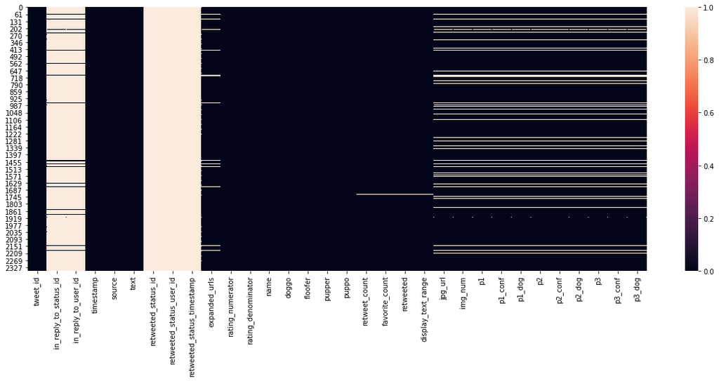

```python
fig, ax = plt.subplots(figsize = (20,7))
ax = sns.heatmap(df_master_clean.isnull(), vmin = 0, vmax = 1)
```

```python
#check with the column from the api table, no retweets left
df_master_clean.retweeted.value_counts()
```

```
False    2168
Name: retweeted, dtype: int64
```

```python
#same as for the retweets, we only want the rows without an entry in "in_reply_to_status_id"
df_master_clean = df_master_clean[df_master_clean.in_reply_to_status_id.isnull()]
```

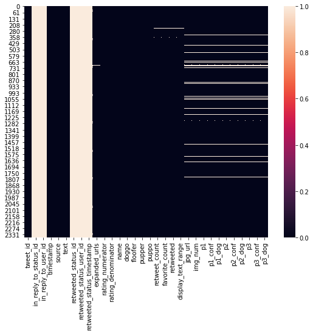

```python
fig, ax = plt.subplots(figsize = (9,7))
ax = sns.heatmap(df_master_clean.isnull(), vmin = 0, vmax = 1)
```

During the gathering process from the API there were some tweets, which got deleted by the account. We will also drop them out of our master dataframe.

```python
df_master_clean.dropna(subset = ["retweeted"], inplace = True)
```

```python
#drop the unneeded columns
df_master_clean.drop(["in_reply_to_status_id", "in_reply_to_user_id",
                      "retweeted_status_id", "retweeted_status_user_id",
                      "retweeted_status_timestamp", "retweeted"], inplace=True, axis = 1)
```

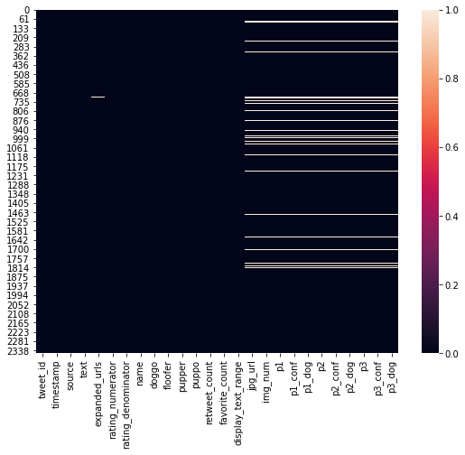

```python
fig, ax = plt.subplots(figsize = (9,7))
ax = sns.heatmap(df_master_clean.isnull(), vmin = 0, vmax = 1)
```

```python
df_master_clean.dropna(subset = ["jpg_url"], inplace = True)
```

```python
sum(df_master_clean.jpg_url.duplicated())
```

```
0
```

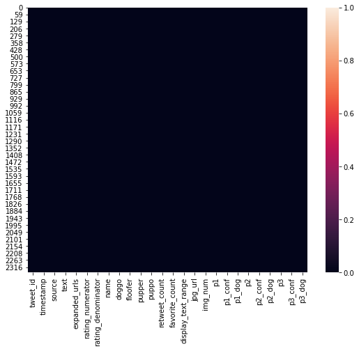

```python
fig, ax = plt.subplots(figsize = (9,7))
ax = sns.heatmap(df_master_clean.isnull(), vmin = 0, vmax = 1)
```

Looks like we have cleaned all the missing data

```python
#to clean all the images that doesnot displays dog
df_master_clean.drop(df_master_clean.query("p1_dog == False and p2_dog == False and p3_dog == False").index, inplace = True)
```

```python
df_master_clean.query("p1_dog == False and p2_dog == False and p3_dog == False")
```

|  | tweet_id | timestamp | source | text | expanded_urls | rating_numerator | rating_denominator | name | doggo | floofer | pupper | puppo | retweet_count | favorite_count | display_text_range | jpg_url | img_num | p1 | p1_conf | p1_dog | p2 | p2_conf | p2_dog | p3 | p3_conf | p3_dog |
| --- | --- | --- | --- | --- | --- | --- | --- | --- | --- | --- | --- | --- | --- | --- | --- | --- | --- | --- | --- | --- | --- | --- | --- | --- | --- | --- |

Test:

```python
df_master_clean.info()
```

```
<class 'pandas.core.frame.DataFrame'>
Int64Index: 1659 entries, 1 to 2355
Data columns (total 26 columns):
 #   Column              Non-Null Count  Dtype
---  ------              --------------  -----
 0   tweet_id            1659 non-null   int64
 1   timestamp           1659 non-null   object
 2   source              1659 non-null   object
 3   text                1659 non-null   object
 4   expanded_urls       1659 non-null   object
 5   rating_numerator    1659 non-null   int64
 6   rating_denominator  1659 non-null   int64
 7   name                1659 non-null   object
 8   doggo               1659 non-null   object
 9   floofer             1659 non-null   object
```

[output cut: 18 more lines]

Define:

Clean the datatypes of the columns